# Distill-flavoured R Markdown for Scientific Manuscripts

5/9/2021

## Overview

- What is Distill R Markdown?
- How to write scientific manuscripts using Distill R Markdown?
- How to publish finished articles using GitHub?

[figure not shown]

## R Markdown

- A framework for creating fully reproducible dynamic documents in R in multiple formats such as
  - Word
  - PDF
  - HTML

### Installation

- Install from CRAN with:

```r
install.packages("rmarkdown")
```

## Distill R Markdown

- An R Markdown template designed for scientific papers
- Best suited for technical and scientific presentations
- Functionalities to insert:
  - author information
  - text
  - tables
  - figures
  - references
  - mathematical symbols or equations (using LaTeX)
  - … and more!

## Let’s take a look at my manuscript! :)

## Get Started with Distill

### Installation:

- Install the released version of distill from CRAN:

```r
install.packages("distill")
```

- Or install the development version from GitHub with:

```r
install.packages("devtools")
devtools::install_github("rstudio/distill")
```

### Loading package:

```r
library(distill)
```

## Creating a Distill article

Via RStudio IDE: File > New File > R Markdown

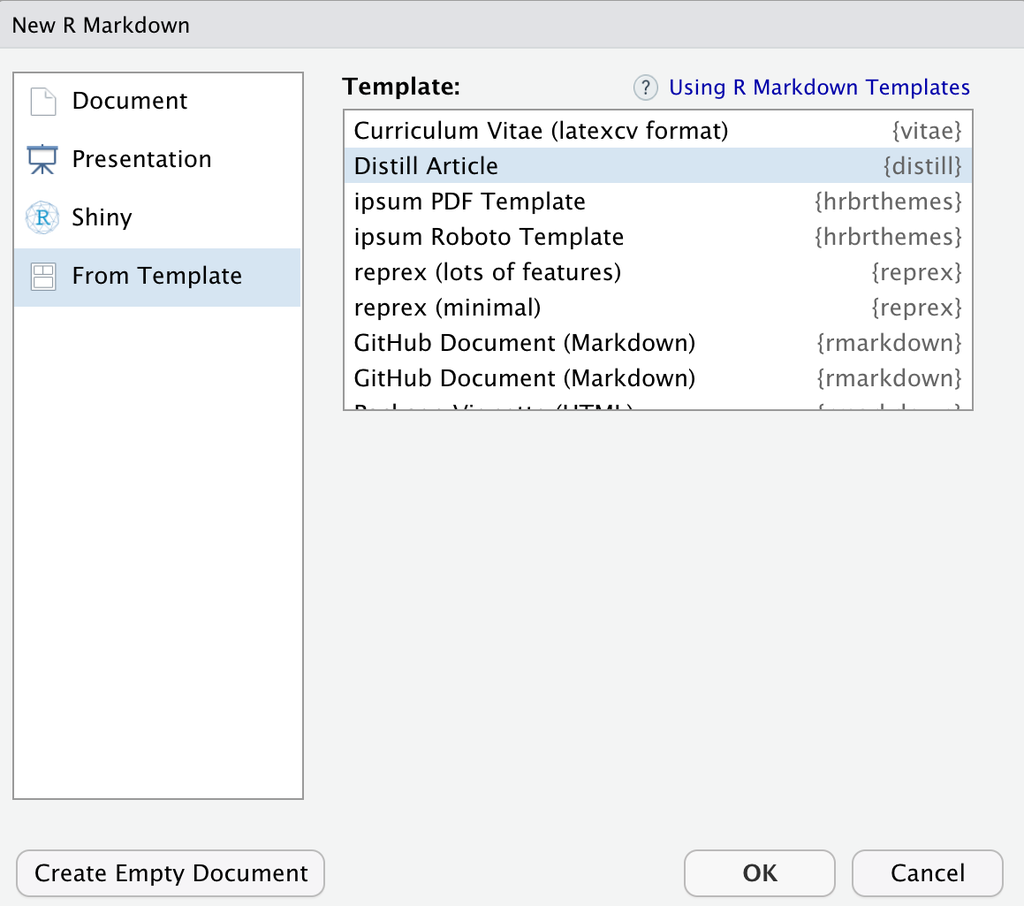

Using command line:

```r
create_article("article.Rmd")
```

## Distill .Rmd file components

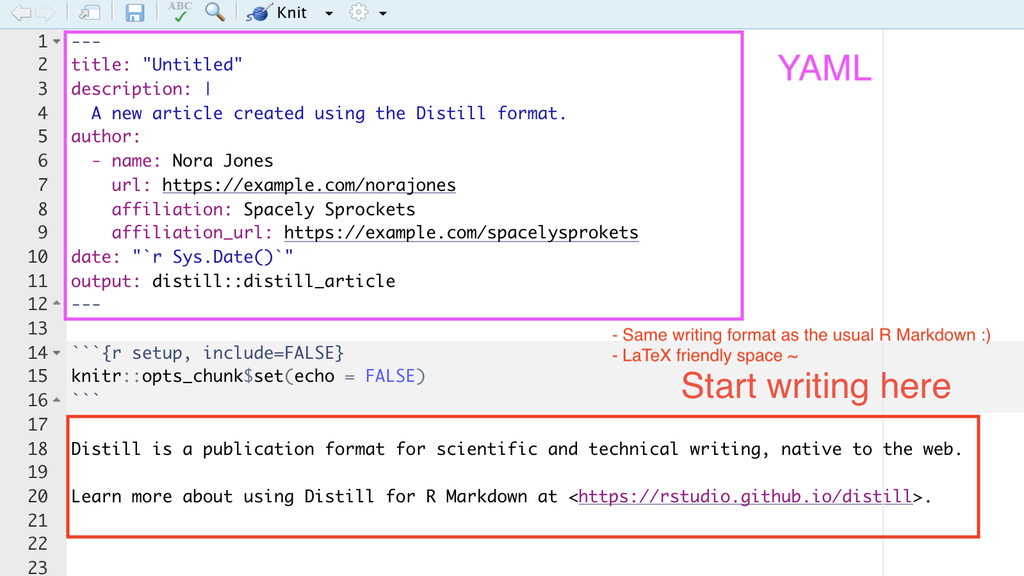

## Images and Tables

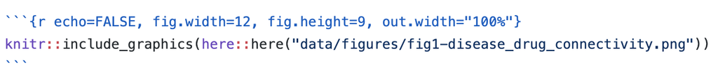

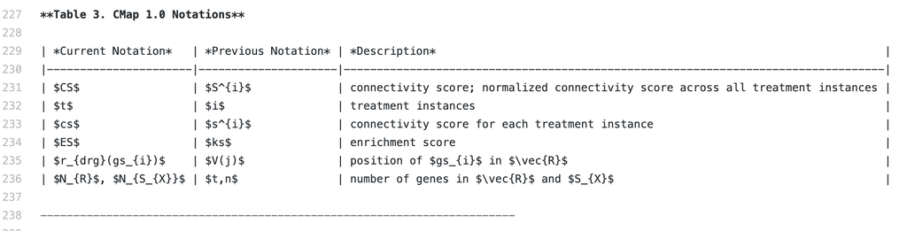

## Mathematical Equations/Symbols

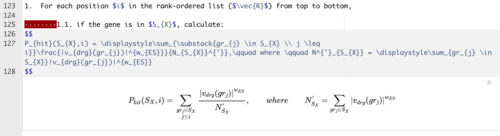

- LaTeX writing format
- https://www.caam.rice.edu/~heinken/latex/symbols.pdf

## Inserting References

- Get bibtex file
  - a text file with `bib` extension containing bibtex citations
  - can be generated manually or automatically created using Zotero, PubMed

[figure not shown]

[figure not shown]

## Inserting References

[figure not shown]

## Inserting References

- Specify path to the bibtex file in YAML

```r
bibliography: refs/bibtex.bib
```

- Use `@citekey` to insert in-text citation

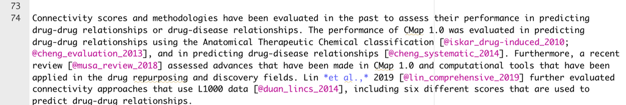

## Demo Time ~

## Resources

Learn more about `Distill`:

- Webpage: https://rstudio.github.io/distill/
- GitHub: https://github.com/rstudio/distill

Links to my work:

- Live Doc: https://jravilab.github.io/connectivity_scores
- GitHub Repo: https://github.com/jravilab/connectivity_scores
- PDF: https://arxiv.org/pdf/2009.09317

Presentation materials:

- GitHub: @KewalinSamart
  - https://github.com/KewalinSamart/Rladies-lightning-talk-distill

**Thank you** :)